# Day 1 — mouse proteins: reading preview

**Reading preview only.** Use `source("scripts/run_day1.R")` in the project to open live editors, feedback and sliders. This page shows starter code, not completed student answers.

## Welcome: you are the analysis team

We measure protein signals in mouse cortex. BDNF is involved in neuronal survival and plasticity. Compare Saline and Memantine groups, then investigate whether BDNF and phosphorylated CREB (pCREB) vary together. These are assay signals in relative units, not direct measurements of memory.

**Your question:** Do BDNF assay signals differ between Saline and Memantine mice, and do BDNF and pCREB vary together?

No previous R or statistics is needed. First we will learn to run a command, then follow the measurements into a figure. You are allowed to be surprised by the data. A result that does not support your prediction is still a result worth explaining.

Work in pairs. One person types and the other predicts or explains; swap after each section. Keep your own written answers. Today stays in this interactive tutorial, including statistics. Tomorrow you will use an RStudio notebook with human MMSE data.

- **Code editor:** type R commands in the box containing code. Click **Run Code** to see results below it.
- **Answer box:** type your scientific explanation in ordinary words.
- **Submit Answer:** save your current code attempt and request feedback. Run Code alone does not save an attempt for download.

Keep the supplied commands and **append your solution underneath**, unless a task explicitly asks you to repair an error. Each editor runs independently: keep its supplied import lines. `#` starts a comment, which R ignores. You can experiment without changing the source data files.

Download regularly. Written answers are session-only; download before closing or reloading. Your notebook contains your submitted code, your explanations and your current slider views. It will become an ordinary editable R notebook in RStudio.

## 1. First successful runs

Click inside the editor and press Enter for a new line. Running an editor runs every line, top to bottom. Output appears in the same order. The printed `[1]` marks the position of the first output item; it is not part of the calculated number.

### Make R do the arithmetic

Run the supplied addition. Then append `12 / 4` on a new line, run again and submit. `/` means divide.

```r
2 + 3

# Add your command below.

# your code goes here
```

### Plan the plate

Three plates, four wells each: how many wells? Predict first. Append `3 * 4`; `*` means multiply.

```r
3 + 4

# Add your command below.

# your code goes here
```

### Give a result a name

An **object** is information kept under a name. Read `wells <- 12` as “store 12 in wells”. The arrow is `<` followed by `-`. A name on its own displays its value. Keep the example, then append `wells <- 16` and `wells` on separate lines.

```r
wells <- 12
wells

# your code goes here
```

### Keep several measurements together: c()

`c()` combines values into a **vector**, an ordered collection. A **function** is a named operation; its inputs go inside parentheses. In `c(2, 4, 6)`, commas separate three values. Nothing is being added yet! Run the example. Then append `counts <- c(2, 4, 6, 8)` and `counts` to keep and display four values.

```r
counts <- c(2, 4, 6)
counts

# your code goes here
```

### An average in two ways: mean()

The **mean** is the sum divided by the number of observations. The example calculates it by hand. Append `mean(counts)`: give the stored vector to the function by putting its name inside parentheses. Does it agree? `length(counts)` reports how many values there are, not their average.

```r
counts <- c(2, 4, 6)
(2 + 4 + 6) / 3
length(counts)

# your code goes here
```

### Predict before you press Run

These are made-up assay readings. Before running, predict whether adding 9 will raise or lower the mean. Keep the example and append a new vector containing 4, 5, 6, 9, then calculate its mean. Explain the change to your partner.

```r
readings <- c(4, 5, 6)
mean(readings)

# your code goes here
```

### Recover from a small error

Run this editor once. R names are case-sensitive: `Readings` and `readings` are different. Repair the capital letter and rerun. In RStudio, a Console prompt of `+` means an unfinished command; press Esc, then repair and rerun the complete command in your notebook.

```r
readings <- c(4, 5, 6)
mean(Readings)

# your code goes here
```

## 2. Meet the mice

One row is one mouse, using assay record 1 from that mouse. The original study measured each sample repeatedly; those repeated readings are not extra mice.

We use **all 72 mice: 34 Saline and 38 Memantine**, with all three protein measurements available at the selected record. **Treatments are unpaired:** each mouse received one treatment; no mouse appears in both groups. The three proteins are measured in the same mouse, which lets us study their association. Both treatment groups contain different genotypes and learning protocols. Pooled comparisons describe this mixed cohort; they do not isolate a drug effect or demonstrate improved memory. The original measurements are real, openly available research data. The preparation and exact source are in `data/dictionary.html`. [Dataset](https://archive.ics.uci.edu/dataset/342/mice+protein+expression) · [Original study](https://doi.org/10.1371/journal.pone.0129126).

| Column | Meaning |
| --- | --- |
| `sample_id` | Animal identifier; a label, not a measured quantity |
| `group` | Saline or Memantine |
| `BDNF` | BDNF assay signal (relative units) |
| `pCREB` | pCREB assay signal (relative units), from the same animal |
| `NR1` | NR1/GluN1 assay signal (relative units), from the same animal |
| `genotype` | Control or Ts65Dn |
| `learning` | C/S or S/C protocol |
| `source_record` | Original assay record retained for traceability |

### What do these proteins do?

- **BDNF — brain-derived neurotrophic factor:** supports neuronal survival and development, and helps synapses change their strength. These changes in connections are part of synaptic plasticity. [BDNF reference](https://www.ncbi.nlm.nih.gov/gene/627).
- **pCREB — phosphorylated CREB:** CREB is a transcription factor, a protein that helps regulate which genes are expressed. Phosphorylation adds a phosphate group and can link signals arriving in a neuron to changes in gene expression. BDNF can stimulate CREB phosphorylation; our pCREB column measures a modified protein signal, not the amount of its RNA. [Experimental study of BDNF and CREB](https://pubmed.ncbi.nlm.nih.gov/9390517/).
- **NR1, also called GluN1:** an essential subunit of the NMDA receptor, a glutamate receptor that forms an ion channel. NMDA receptors contribute to synaptic plasticity involved in learning and memory. Measuring the subunit’s assay signal does not directly measure receptor current. [NR1 reference](https://www.ncbi.nlm.nih.gov/gene/2902).

A table in R is called a **data frame**. A row holds information about one animal; a column holds one variable. A **nominal** category names groups with no ranking; an **ordinal** category has an order but need not have equal gaps. A **continuous** measurement can take intermediate values even if the instrument rounds them. Biological meaning matters, not just whether R stores digits. For example, a hypothetical severity rating of mild, moderate or severe is ordinal: the gaps need not be equal. This rating is an illustration, not a column in the mouse data.

### Open the table

`read.csv()` reads a comma-separated table. Quotes mark literal text, including a file path. `<-` stores the table as study. `head()` previews rows, `names()` lists columns, and `dim()` reports rows then columns. Run the supplied import, then append `head(study)`, `names(study)` and `dim(study)` in that order.

```r
study <- read.csv("data/study.csv")

# your code goes here
```

```
## Describe one row, the measurement and its unit. Is group nominal or ordinal? Is BDNF a continuous measurement? Explain why an ID is a label even when it contains digits.
```

### Are 1,080 readings 1,080 mice?

The original assay has 15 records per mouse: replicates across a dilution series. They are not new animals. Our teaching table retains record 1 consistently for each mouse. `unique()` keeps distinct labels and `length()` counts them. Complete the two assignments by replacing `NULL`: use `nrow(records)` for measurements and `length(unique(records$sample_id))` for mice. Different IDs alone do not prove independence; cage, litter and allocation can also matter.

```r
records <- read.csv("data/replicates.csv")
measurement_n <- NULL # Replace NULL
mouse_n <- NULL       # Replace NULL
measurement_n
mouse_n

# your code goes here
```

```
## If someone copies every row twice, have we doubled the biological sample size? Report measurements and mice separately; explain what a row in study.csv represents.
```

### Classify every column

For each column in `study`, choose **ordinal**, **nominal** or **continuous** based on its meaning. You may use the same answer more than once; not every answer has to occur. Identifiers belong with nominal labels in this exercise. Submit each answer to see feedback.

| Column | Your choice: ordinal, nominal or continuous |
| --- | --- |
| `sample_id` | Write your choice |
| `group` | Write your choice |
| `BDNF` | Write your choice |
| `pCREB` | Write your choice |
| `NR1` | Write your choice |
| `genotype` | Write your choice |
| `learning` | Write your choice |
| `source_record` | Write your choice |

## 3. Follow one group

Sometimes we want **one column** from a table, such as all BDNF measurements. Sometimes we want **a subset of rows**, such as only mice that received Saline. We can combine these two selections.

1. **Take a column with `$`.** `study$BDNF` means “the BDNF column of study”. `study$group` gives the treatment label for every mouse, in the same row order.
2. **Compare with `==`.** `study$group == "Saline"` asks “is this value equal to Saline?” for each row. It returns `TRUE` for a Saline mouse and `FALSE` otherwise. Quotes tell R that `"Saline"` is literal text. **Two equals signs compare; `<-` stores a result.**
3. **Keep the selected values with `[ ]`.** `study$BDNF[study$group == "Saline"]` starts with the BDNF column and keeps the entries whose treatment comparison is `TRUE`.

```r
study <- read.csv("data/study.csv")
head(study$group)             # One column: the first treatment labels
```

```
## [1] "Memantine" "Memantine" "Memantine" "Memantine" "Memantine" "Memantine"
```

```r
head(study$group == "Saline") # One TRUE/FALSE decision for each of these rows
```

```
## [1] FALSE FALSE FALSE FALSE FALSE FALSE
```

```r
head(study$BDNF[study$group == "Saline"]) # BDNF values only for Saline mice
```

```
## [1] 0.4149799 0.4190171 0.3608175 0.3979228 0.4370483 0.4971599
```

If we want **all columns for the selected mice**, use `study[study$group == "Saline", ]`. For a table, the position before the comma selects rows; the empty position after it keeps every column. Compare that with selecting just the BDNF values above. The templates are here to adapt, not memorise.

The name `saline_bdnf` tells us both the biological measurement and its group. We will use `memantine_bdnf` for the other group. Descriptive names help you check which animals a calculation includes.

### Follow the Memantine animals

Run the Saline example. Append a selection for `"Memantine"`, store it as `memantine_bdnf`, then append `length(memantine_bdnf)` and `mean(memantine_bdnf)`. Say which animals contributed before reading the mean.

```r
study <- read.csv("data/study.csv")
saline_bdnf <- study$BDNF[study$group == "Saline"]
length(saline_bdnf)
mean(saline_bdnf)

# your code goes here
```

```
## Which animals contributed to memantine_bdnf? Explain the selection to your partner.
```

## 4. Centre, spread and the middle half

The mean gives each observation equal weight. The **median** is the middle of the ordered observations (the mean of the two middle ones when there is an even number). The **sample standard deviation (SD)** describes variation among observations, in the same units as the measurement. A larger SD means more variation; it does not by itself tell us how uncertain the mean is. Sample size also matters for that.

### Which group varies more?

Run the supplied mean and median calculations. Append `sd_saline_bdnf <- sd(saline_bdnf)` and `sd_memantine_bdnf <- sd(memantine_bdnf)`, then display each named result on its own line. Compare the SDs in your answer.

```r
study <- read.csv("data/study.csv")
saline_bdnf <- study$BDNF[study$group == "Saline"]
memantine_bdnf <- study$BDNF[study$group == "Memantine"]
mean(saline_bdnf)
median(saline_bdnf)
mean(memantine_bdnf)
median(memantine_bdnf)

# your code goes here
```

```
## Write both SDs with units. Which group varies more? Does that tell you how precisely its mean is known?
```

### Where is the middle half?

Quartiles mark positions in ordered observations. Q1 is the 25th percentile, Q2 the median, and Q3 the 75th percentile. **IQR = Q3 − Q1**, in the measurement’s units. It describes spread of the middle half and is less sensitive to extremes than the range. The supplied commands calculate Saline quartiles. Add `memantine_q <- quantile(memantine_bdnf, probs = c(0.25, 0.5, 0.75))` and `memantine_iqr <- IQR(memantine_bdnf)`, then display both. Compare with `memantine_q[3] - memantine_q[1]`; square brackets here select a position in the vector.

```r
study <- read.csv("data/study.csv")
saline_bdnf <- study$BDNF[study$group == "Saline"]
memantine_bdnf <- study$BDNF[study$group == "Memantine"]
quantile(saline_bdnf, probs=c(0.25,0.5,0.75))
IQR(saline_bdnf)
# Add the Memantine calculations here.

# your code goes here
```

```
## Report Memantine Q1, median, Q3 and IQR with units. Complete: the middle half lies approximately between ___ and ___. Why is this not an interval for uncertainty in the mean?
```

### Challenge: double the headline

A colleague reports that “the average response doubled”. Four of five made-up culture readings are fixed at 4, 5, 5 and 6. Only the fifth reading can change. Can you double the original mean without changing the median? Work out a candidate before moving the slider. These are separate invented readings, not edits to our animal measurements.

*Live slider: change the fifth reading, observe mean and median, then test your prediction in code.*

### Test the headline in code

Keep the original readings. Append a new assay vector with your chosen fifth value, then `new_mean <- mean(assay)` and `new_median <- median(assay)`. Display both results. Bonus: with the other four readings fixed, which median values are even possible?

```r
assay <- c(4, 5, 5, 6, 7)
mean(assay)
median(assay)

# your code goes here
```

```
## Which fifth reading doubles the mean? Why can the median stay fixed? Critique: “The average doubled, so every culture responded twice as much.” What would you check before deleting the unusual reading?
```

## 5. The assay that failed

`NA` means missing. It does not mean zero. Imagine one assay failed: would writing zero describe what happened? First predict what R should do when a required input is unknown. Then compare two decisions using these invented values; keep the source table untouched.

### Missing is a different claim from zero

Run the starter: `mean(example)` returns NA. Count the recorded numbers by looking at the vector. Append `observed_n <- 3` and `observed_mean <- mean(example, na.rm = TRUE)`. The comma introduces another argument; `na.rm = TRUE` excludes missing entries for this calculation only. In a separate vector called `zero_example`, use 0 instead of NA; calculate `zero_mean <- mean(zero_example)`. Display the count and both means.

```r
example <- c(4, 6, NA, 8)
mean(example)
observed_n <- length(example) # Change: count observed values, excluding NAs

# your code goes here
```

```
## How many observations contributed to observed_mean? Explain why inserting zero changes the scientific meaning. What if the assay fails more often for very high values?
```

Excluding a missing value does not recover it. If high values fail more often, the observed values may systematically miss the high end of the distribution.

**Take a break.** On return, swap typing and explanation roles.

## 6. How many bars tell the story?

A **histogram** groups measurements into intervals called bins. Bar height counts observations inside each interval. A few broad bins can hide structure; many narrow bins can make a small sample look full of gaps. Neither setting adds information. The marks below the bars show where the actual observations lie. Both groups below use the same bins and axes.

Try to make the data look as smooth as possible, then as irregular as possible. Ask your partner which biological conclusions survive both views. This is a challenge to the display, not an invitation to select whichever plot supports your preferred story.

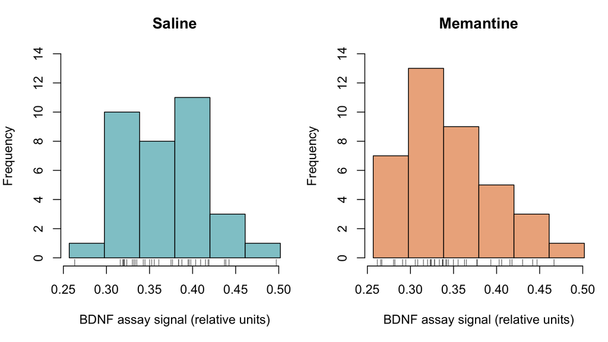

### Make a histogram you can rerun

`hist()` draws a histogram. The supplied `seq()` creates six shared bins spanning all 72 BDNF values. Both plots use these boundaries and the same x-axis limits, so the comparison stays fair. `main` sets the title and `xlab` labels the horizontal axis. Keep the Saline example and append `hist_memantine_bdnf <- hist(memantine_bdnf, breaks = shared_breaks, xlim = shared_xlim, main = "Memantine", xlab = "BDNF assay signal (relative units)")`.

```r
study <- read.csv("data/study.csv")
saline_bdnf <- study$BDNF[study$group == "Saline"]
memantine_bdnf <- study$BDNF[study$group == "Memantine"]
shared_xlim <- range(study$BDNF)
shared_breaks <- seq(shared_xlim[1], shared_xlim[2], length.out=7)
hist(saline_bdnf, breaks=shared_breaks, xlim=shared_xlim, main="Saline", xlab="BDNF assay signal (relative units)")

# your code goes here
```

```
## Describe one pattern that survives changing bins and one apparent feature that disappears. What can this small sample tell us about population shape?
```

## 7. Show the animals behind the average

A **boxplot** puts the middle half of the observations inside a box. The line is the median. Whiskers extend to the most distant observations within 1.5 box lengths of the box; more distant observations are conventionally drawn separately. These points deserve investigation, not automatic deletion. Always look at the actual observations as well. The box is the middle half, not a confidence interval. R boxplot hinges and quantile() quartiles can differ slightly, especially in small samples.

In R’s plot formula `BDNF ~ group`, read `~` as “shown by group”. `data = study` tells R where those column names live. `stripchart()` adds individual observations. Jitter moves points sideways slightly to reveal overlap; it never changes their measured height. `set.seed(7)` makes that sideways movement repeatable.

### Can the mean-only chart tell the whole story?

Run the supplied bar chart, which shows only two means. Append the following worked template to add a boxplot with all animals. Run, inspect and submit. You do not need to invent the plotting syntax.

```r
study$group <- factor(study$group, levels=c("Saline","Memantine")) # Fix group order for consistent plots; measurements stay unchanged.
comparison <- boxplot(BDNF ~ group, data=study, outline=FALSE,
  ylab="BDNF assay signal (relative units)", xlab="Group", col=c("lightblue","peachpuff"))
set.seed(7)
stripchart(BDNF ~ group, data=study, vertical=TRUE, method="jitter",
  jitter=0.1, add=TRUE, pch=16)
```

```r
study <- read.csv("data/study.csv")
saline_bdnf <- study$BDNF[study$group == "Saline"]
memantine_bdnf <- study$BDNF[study$group == "Memantine"]
barplot(c(mean(saline_bdnf),mean(memantine_bdnf)),names.arg=c("Saline","Memantine"),
  ylab="Mean: BDNF assay signal (relative units)",main="Only the means")

# your code goes here
```

```
## What do the individual points reveal that a mean-only chart hides? Write a caption with units, group sizes, one pattern and one limitation.
```

### A smooth violin from a small sample?

A violin’s width estimates where measurements are more concentrated. The dots are observed; the smooth outline is calculated. Each violin here has equal maximum width and stops at its observed range; width does not encode sample size or a confidence interval. The short line is the median. Change the smoothing: can you make a bump vanish without changing a single animal?

```
## Change the smoothing slider. Did any observations change? What part of the violin was estimated rather than measured?
```

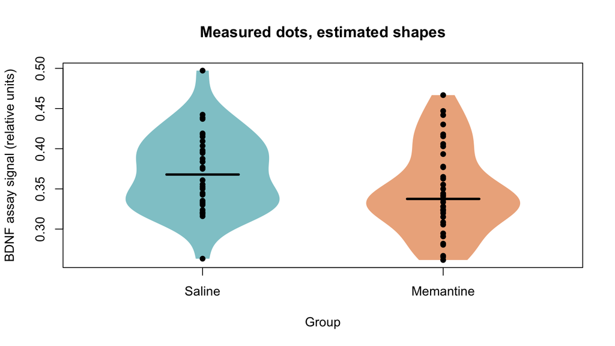

## 8. Two measurements from the same animal

A **scatterplot** gives each animal one point. Its horizontal and vertical positions show two different measurements from that animal. A rising pattern suggests positive association; a falling pattern suggests negative association. First inspect a single group, so a difference between groups is not mistaken for a relationship within a group.

### Does the pattern travel to the other group?

In `study[condition, ]`, the part before the comma selects rows and the blank after it keeps all columns. Run the supplied Saline plot. Append the same three commands for Memantine, naming the selected table `memantine_mice`. Keep the same measurement axes and label the group.

```r
study <- read.csv("data/study.csv")
saline_mice <- study[study$group == "Saline", ]
plot(saline_mice$BDNF, saline_mice$pCREB,
  xlab="BDNF assay signal (relative units)", ylab="pCREB assay signal (relative units)", main="Saline", pch=19)

# your code goes here
```

```
## Describe the association within the selected group: upward, downward or unclear? Could this plot establish that one measurement causes the other?
```

## 9. Is a normal model a useful approximation?

A **normal distribution** is a symmetric bell-shaped model. Real observations may be skewed (one tail longer), bounded or contain unusual values. Similar means and medians do not prove normality. Inspect groups separately: pooling groups can hide or invent shapes.

### What does a Q–Q plot compare?

Q–Q means **quantile–quantile**. You already used quartiles to locate the lower quarter, middle and upper quarter of your measurements. A Q–Q plot extends that idea across the whole distribution: it compares many ordered positions, not just three quartiles.

For a **normal Q–Q plot**, R sorts your measurements from smallest to largest. Each dot compares an observed value on the **vertical axis** with the position expected in a standard normal distribution on the **horizontal axis**. The horizontal values are theoretical quantiles, not additional mice. The vertical axis stays in assay units.

- **Dots roughly follow a straight line:** the observed distribution is reasonably compatible with a normal shape. The line need not have slope 1; different means and SDs move or tilt it.
- **Systematic bends or an S-shaped pattern:** the distribution may have skew or tails that differ from a normal model.
- **A few end points far from the line:** inspect the extreme observations. This is a reason to investigate, not automatically delete them.

`qqnorm()` draws the dots. `qqline()` adds a reference line through the first and third quartiles, linking this plot to the summaries you calculated earlier. Random variation means that real data rarely sit exactly on the line, especially in small samples. [R Q–Q plot reference](https://stat.ethz.ch/R-manual/R-devel/library/stats/html/qqnorm.html).

### What does the Shapiro–Wilk test tell us?

**Shapiro–Wilk** is a statistical test of the null hypothesis that the independent observations come from a normal distribution. It compares the pattern of ordered measurements with the pattern expected under normality. R reports a statistic called **W** and a **p-value**. W values closer to 1 indicate closer agreement with the normal pattern; use the p-value, sample size and plots to interpret the evidence, rather than a fixed W cutoff.

The **p-value** asks: *if the normal model and the test’s assumptions held, how likely would we be to get a test statistic showing at least this much departure from normality?* It is **not** the probability that our data are normal.

For this exercise, choose a significance threshold of **0.05** before reading the result:

| Shapiro–Wilk result | Interpretation | Example |
| --- | --- | --- |
| **p < 0.05** | Reject the normality null at this threshold: there is evidence of a departure from a normal distribution. Inspect the plot to understand the departure. | p = 0.02: evidence against a normal model. It does not mean a 2% probability that the data are normal. |
| **p ≥ 0.05** | Do not reject the normality null: this test has not provided enough evidence of a departure. This does **not prove normality**. | p = 0.30: insufficient evidence against normality, not a 30% probability of normality. |

We use p < 0.05 as the rejection rule here; an exactly reported 0.05 is the boundary, and rounded values can hide which side it falls on. Values just either side of the threshold are not sharply different biological findings.

With few observations, the test may miss substantial departures; with many, it can detect small departures that have little practical impact. A p-value above 0.05 does not override a clearly curved Q–Q plot, and one below 0.05 does not automatically require a rank test. We must still ask what we want to compare, whether observations are independent, and whether the departures matter for the proposed analysis. [R Shapiro–Wilk reference](https://stat.ethz.ch/R-manual/R-devel/library/stats/html/shapiro.test.html).

**Before running:** explain to your partner how you would describe p = 0.02 and p = 0.30. Then check both the plots and test results for our mice.

### Inspect the other group

Run the Saline example. Add `qqnorm(memantine_bdnf)` followed by `qqline(memantine_bdnf)`. Save `shapiro.test(memantine_bdnf)` as `normal_check` and display it. Explain the plots before reading the p-value.

```r
study <- read.csv("data/study.csv")
saline_bdnf <- study$BDNF[study$group == "Saline"]
memantine_bdnf <- study$BDNF[study$group == "Memantine"]
qqnorm(saline_bdnf, main="Saline: normal Q-Q plot")
qqline(saline_bdnf)
shapiro.test(saline_bdnf)

# your code goes here
```

```
## Describe one feature of each group plot. Is a normal approximation plausible, and what remains uncertain? What would be wrong with choosing a test only from Shapiro p > 0.05?
```

**Take a break. Submit your latest attempts and download a checkpoint before leaving.**

## 10. Compare groups, then defend the claim

Our question is about **Memantine minus Saline** BDNF signal. Predict the direction before testing. Welch’s t-test compares population means while allowing unequal variances. Independent animals are essential; strong skew and influential values can make small-sample inference fragile. The null hypothesis is equal population means. We do not need a preliminary equal-variance test.

### Estimate first; p-value second

Complete the assignments: `mean_difference <- mean(memantine_bdnf) - mean(saline_bdnf)` and `welch_result <- t.test(memantine_bdnf, saline_bdnf)`. Display the difference, result and `welch_result$conf.int`. Read the means and confidence interval before the p-value. A 95% confidence-interval procedure covers the true difference in about 95% of repeated studies under its assumptions. It does not enclose 95% of mice. A p-value is not the probability that the null hypothesis is true and does not measure biological importance.

```r
study <- read.csv("data/study.csv")
saline_bdnf <- study$BDNF[study$group == "Saline"]
memantine_bdnf <- study$BDNF[study$group == "Memantine"]
mean_difference <- NULL # Replace NULL
welch_result <- NULL    # Replace NULL
mean_difference
welch_result

# your code goes here
```

```
## In this cohort, Memantine was ___ units higher/lower on average (95% CI ___ to ___; n = ___ and ___; p = ___). What can and cannot be concluded? Distinguish individual variation (SD) from uncertainty in a mean difference.
```

### Do the conclusions depend on the question?

Ranks replace measurements with their order. Wilcoxon rank-sum uses ranks; it does not generally test a median difference unless additional shape assumptions apply. It still needs independent animals. Add `rank_result <- wilcox.test(memantine_bdnf, saline_bdnf, exact = FALSE)` and display it. `exact = FALSE` requests an approximation. Keep both results; never select the smaller p-value as your preferred method.

```r
study <- read.csv("data/study.csv")
saline_bdnf <- study$BDNF[study$group == "Saline"]
memantine_bdnf <- study$BDNF[study$group == "Memantine"]
t.test(memantine_bdnf, saline_bdnf)

# your code goes here
```

```
## Which method would you lead with, and what does it ask? Describe whether the conclusions agree. Explain why p > 0.05 would not prove equivalence. Write a headline your partner cannot reasonably call an overclaim.
```

Both groups mix genotype and learning protocol. The source assays a nuclear cortex fraction; its signal is not an absolute concentration or a direct memory score. Inspect the tables below. A pooled comparison describes this cohort and does not isolate a drug mechanism. There may also be cage/litter dependence not documented in the table.

```r
study <- read.csv("data/study.csv")
table(study$group, study$genotype)
```

```
##
##             Control Ts65Dn
##   Memantine      20     18
##   Saline         18     16
```

```r
table(study$group, study$learning)
```

```
##
##             C/S S/C
##   Memantine  19  19
##   Saline     16  18
```

## 11. Put a number on an association

Use two measurements from the **same mouse**, with different mice independent. Pearson describes a linear association; Spearman describes monotonic rank association (generally rising or falling). Both range from −1 to +1. Zero does not exclude every curved relationship. Inspect the scatterplot before choosing; separate Shapiro tests do not select a correlation method. The usual Pearson test and interval additionally need an appropriate model for the paired measurements. Neither coefficient proves causation.

### Choose an association method

Write your reason in the answer box, then replace `"choose"` with `"pearson"` or `"spearman"`. Replace NULL with `cor.test(mice$BDNF, mice$pCREB, method = association_method, exact = FALSE)`. Either choice can pass the code check; your plot and scientific question must justify it. Read the coefficient, sample size and p-value. Report an interval if supplied; base R does not supply a Spearman interval.

```r
study <- read.csv("data/study.csv")
mice <- study[study$group == "Memantine", ]
plot(mice$BDNF, mice$pCREB, pch=19,
     xlab="BDNF (relative units)", ylab="pCREB (relative units)")
association_method <- "choose"
association_result <- NULL # Replace NULL after selecting a method
association_result

# your code goes here
```

```
## Before running: which coefficient and why? Afterwards: report direction, coefficient, n and p-value (CI if provided). What other factor or shared assay process could explain the pattern?
```

## 12. Three proteins, three chances for a small p-value

Suppose we planned three treatment comparisons, one each for BDNF, pCREB and NR1 (an NMDA receptor subunit signal). They form a family of three tests. We supply their Welch p-values below; you do not need to write a loop or repeat three complete analyses. The assumptions and cohort limitations still apply to each comparison.

Bonferroni multiplies each p-value by the number of tests, capped at 1. This controls the chance of at least one false rejection in that family when the individual tests are valid, including when tests are dependent. It does not repair confounding. These three adjusted results do not cover additional correlation tests or undisclosed searches.

### Keep every result in view

Run the supplied three comparisons. Append `adjusted_p <- p.adjust(raw_p, method = "bonferroni")` and `data.frame(raw_p, adjusted_p)`. Compare both columns using a declared 0.05 threshold. A non-significant result still belongs in the report. The estimated group differences have not changed.

```r
study <- read.csv("data/study.csv")
saline <- study[study$group == "Saline", ]
memantine <- study[study$group == "Memantine", ]
raw_p <- c(BDNF=t.test(memantine$BDNF, saline$BDNF)$p.value,
           pCREB=t.test(memantine$pCREB, saline$pCREB)$p.value,
           NR1=t.test(memantine$NR1, saline$NR1)$p.value)
raw_p

# your code goes here
```

```
## Name the family. Which p-values are below 0.05 before and after correction? Why is reporting only the smallest raw value misleading? Do adjusted values change the biological effect size?
```

## 13. Your evidence briefing

Choose your best plot. Explain its axes, sample, result and biggest limitation to your partner. Then swap. A result that contradicts your prediction can make a good report.

```
## One thing I can now do in R; one thing I still need help with; one claim these data cannot support.
```

```
## If you used an LLM or another source: I asked for __; I checked __; I now understand __.
```

**Save before you leave:** click Submit Answer after the last edit in every exercise, download, and keep the file in the project’s `notebooks/` folder. The download contains submitted code and current written answers; unsubmitted edits are not included. Written answers are session-only, so download before closing or refreshing. No RStudio editing is required today.

Tomorrow open **notebooks/02_mmse_investigation.Rmd** in RStudio. It is your clean report template. The mouse practice notebook is a reference; the MMSE report is the individual HTML you submit. Keep the whole project folder and your editable Rmd files.

### Extra practice if you finish early

Use the summary editor to calculate the pCREB median and IQR, retaining the required BDNF commands. Explain whether an IQR can be negative. Alternatively, invent five explicitly hypothetical assay readings whose mean exceeds their median, and explain the shape. These are practice vectors, not replacements for research measurements.